# Regresión Logística y Naive Bayes

# Bibliotecas

```r
library(caret)
library(pROC)
library(e1071)
library(tidyverse)
library(ggpubr)
library(scales)

source("./R/Utils.R")
```

# Variables Globales, constantes y otros

```r
PATH_DATOS <- "./data/bd_final.csv"
SEP_COLUMNAS <- ";"
SEP_DECIMAL <- "."

SEED <- 987
PORCENTAJE_TRAIN <- .8
VALOR_LAPLACE <- 1

VARIABLES_LOGISTICA <- c("diagnostico_pro", "d1", "d2", "d3", "d4", "d5", "edad", "id")
VARIABLES_BAYES <- c("id",
                     "d1",
                     "es_cuidador",
                     "educ",
                     "empleo",
                     "estado_marital",
                     "facilidad_celular",
                     "fumo",
                     "diagnostico_pro",
                     "F0semitoneFrom27.5Hz_sma3nz_amean",
                     "F0semitoneFrom27.5Hz_sma3nz_stddevNorm",
                     "F0semitoneFrom27.5Hz_sma3nz_percentile20.0",
                     "F0semitoneFrom27.5Hz_sma3nz_percentile50.0",
                     "F0semitoneFrom27.5Hz_sma3nz_percentile80.0",
                     "F0semitoneFrom27.5Hz_sma3nz_pctlrange0.2",
                     "F0semitoneFrom27.5Hz_sma3nz_meanRisingSlope",
                     "F0semitoneFrom27.5Hz_sma3nz_stddevRisingSlope",
                     "F0semitoneFrom27.5Hz_sma3nz_meanFallingSlope",
                     "F0semitoneFrom27.5Hz_sma3nz_stddevFallingSlope",
                     "jitterLocal_sma3nz_amean",
                     "jitterLocal_sma3nz_stddevNorm",
                     "shimmerLocaldB_sma3nz_amean",
                     "shimmerLocaldB_sma3nz_stddevNorm")
```

# Cargar datos

```r
datos_crudos <- read.table(PATH_DATOS, sep = SEP_COLUMNAS, dec = SEP_DECIMAL, header = TRUE)
glimpse(datos_crudos)
```

```
Rows: 2,218
Columns: 39
$ id                                             <int> 24665, 21472, 25155, 22829, 24848, 21417, 25652, 23500, 22216, 23967, 24861, 23331, 27236,...
$ d1                                             <dbl> 35.23343, 35.06466, 53.76691, 31.19639, 36.34814, 34.78511, 35.44090, 34.05800, 30.03747, ...
$ d2                                             <dbl> -178.85030, -177.20320, -178.88640, -197.15470, -117.80970, -191.45730, -146.54980, -128.1...
$ d3                                             <dbl> 0.374910, 0.379995, 0.359551, 0.325620, 0.271464, 0.395302, 0.387376, 0.299799, 0.359066, ...
$ d4                                             <dbl> 0.096570, 0.115948, 0.109389, 0.103234, 0.102776, 0.120893, 0.083093, 0.089153, 0.102191, ...
$ d5                                             <dbl> 0.032114, 0.024917, 0.058175, 0.069262, 0.005820, 0.016126, 0.064559, 0.040827, 0.055805, ...
$ edad                                           <int> 71, 48, 73, 50, 57, 51, 56, 52, 64, 36, 52, 72, 73, 61, 65, 67, 72, 83, 55, 71, 56, 65, 60...
$ es_cuidador                                    <chr> "true", "false", "false", "false", "false", "false", "false", "false", "false", "false", "...
$ dbs                                            <chr> "false", NA, "false", "false", "false", "false", "false", "false", "false", NA, "false", "...
$ anio_diagnostico                               <int> 2011, NA, 2005, 2014, 2012, 2010, 2014, 1996, 2005, NA, 2014, 2011, 2013, 2003, 2010, 2005...
$ educ                                           <chr> "High School Diploma/GED", "Some college", "Some college", "High School Diploma/GED", "4-y...
$ empleo                                         <chr> "Retired", "Employment for wages", "Retired", "Self-employed", "Self-employed", "Employmen...
$ genero                                         <chr> "Female", "Male", "Male", "Male", "Female", "Male", "Female", "Female", "Male", "Female", ...
```

[output cut: 26 more lines]

Primero transfromamos todas las variables del tipo character como factores

```r
datos <- datos_crudos %>%
  map_dfc(~ if(is.character(.x)) { factor(.x) } else { .x })

glimpse(datos)
```

```
Rows: 2,218
Columns: 39
$ id                                             <int> 24665, 21472, 25155, 22829, 24848, 21417, 25652, 23500, 22216, 23967, 24861, 23331, 27236,...
$ d1                                             <dbl> 35.23343, 35.06466, 53.76691, 31.19639, 36.34814, 34.78511, 35.44090, 34.05800, 30.03747, ...
$ d2                                             <dbl> -178.85030, -177.20320, -178.88640, -197.15470, -117.80970, -191.45730, -146.54980, -128.1...
$ d3                                             <dbl> 0.374910, 0.379995, 0.359551, 0.325620, 0.271464, 0.395302, 0.387376, 0.299799, 0.359066, ...
$ d4                                             <dbl> 0.096570, 0.115948, 0.109389, 0.103234, 0.102776, 0.120893, 0.083093, 0.089153, 0.102191, ...
$ d5                                             <dbl> 0.032114, 0.024917, 0.058175, 0.069262, 0.005820, 0.016126, 0.064559, 0.040827, 0.055805, ...
$ edad                                           <int> 71, 48, 73, 50, 57, 51, 56, 52, 64, 36, 52, 72, 73, 61, 65, 67, 72, 83, 55, 71, 56, 65, 60...
$ es_cuidador                                    <fct> true, false, false, false, false, false, false, false, false, false, false, false, false, ...
$ dbs                                            <fct> false, NA, false, false, false, false, false, false, false, NA, false, false, false, false...
$ anio_diagnostico                               <int> 2011, NA, 2005, 2014, 2012, 2010, 2014, 1996, 2005, NA, 2014, 2011, 2013, 2003, 2010, 2005...
$ educ                                           <fct> High School Diploma/GED, Some college, Some college, High School Diploma/GED, 4-year colle...
$ empleo                                         <fct> Retired, Employment for wages, Retired, Self-employed, Self-employed, Employment for wages...
$ genero                                         <fct> Female, Male, Male, Male, Female, Male, Female, Female, Male, Female, Female, Female, Fema...
```

[output cut: 26 more lines]

# Regresión Logística

Vamos a armar una regresión logística con diagnostico_pro como respuesta y las variables d1, d2, d3, d4, d5 y edad como predictoras.

Observamos los NAs para las variables leegidas

```r
vector_cant_nas <- datos %>%
  select(all_of(VARIABLES_LOGISTICA)) %>%
  map_int(~ sum(is.na(.x)))

vector_cant_nas[vector_cant_nas > 0]
```

```
named integer(0)
```

No se observan NAs en las variables a usar, ahora apartamos las varaibles que vamos a utilizar en el modelo.

```r
datos_log <- datos %>%
  select(all_of(VARIABLES_LOGISTICA))

glimpse(datos_log)
```

```
Rows: 2,218
Columns: 8
$ diagnostico_pro <fct> true, false, true, true, true, true, true, true, true, false, true, true, true, true, true, true, true, true, true, true,...
$ d1              <dbl> 35.23343, 35.06466, 53.76691, 31.19639, 36.34814, 34.78511, 35.44090, 34.05800, 30.03747, 34.89442, 40.43251, 33.88995, 3...
$ d2              <dbl> -178.85030, -177.20320, -178.88640, -197.15470, -117.80970, -191.45730, -146.54980, -128.15140, -187.36390, -144.80920, -...
$ d3              <dbl> 0.374910, 0.379995, 0.359551, 0.325620, 0.271464, 0.395302, 0.387376, 0.299799, 0.359066, 0.411853, 0.179618, 0.206692, 0...
$ d4              <dbl> 0.096570, 0.115948, 0.109389, 0.103234, 0.102776, 0.120893, 0.083093, 0.089153, 0.102191, 0.104457, 0.072908, 0.086952, 0...
$ d5              <dbl> 0.032114, 0.024917, 0.058175, 0.069262, 0.005820, 0.016126, 0.064559, 0.040827, 0.055805, 0.072490, 0.003754, 0.010177, 0...
$ edad            <int> 71, 48, 73, 50, 57, 51, 56, 52, 64, 36, 52, 72, 73, 61, 65, 67, 72, 83, 55, 71, 56, 65, 60, 66, 57, 53, 67, 46, 36, 69, 7...
$ id              <int> 24665, 21472, 25155, 22829, 24848, 21417, 25652, 23500, 22216, 23967, 24861, 23331, 27236, 27313, 25626, 27036, 25824, 25...
```

Dividimos los datos

```r
set.seed(SEED)
indices_train_log <- createDataPartition(datos_log$diagnostico_pro,
                                         p = PORCENTAJE_TRAIN,
                                         list = FALSE) %>%
  as.vector()

datos_log_train <- datos_log[indices_train_log,]
datos_log_test <- datos_log[-indices_train_log,]

nrow(datos_log_train)
```

```
[1] 1775
```

```r
nrow(datos_log_test)
```

```
[1] 443
```

Entrenamos el modelo con las particiones

```r
modelo_log <- train(diagnostico_pro ~ .,
                    data = datos_log_train %>% select(-id),
                    method = "glm",
                    family= "binomial")

summary(modelo_log)
```

```
Call:
NULL

Deviance Residuals:
    Min       1Q   Median       3Q      Max
-2.6491  -0.7087  -0.3894   0.8077   2.4769

Coefficients:
             Estimate Std. Error z value Pr(>|z|)
(Intercept) -8.969971   0.506961 -17.694  < 2e-16 ***
d1           0.087917   0.014434   6.091 1.12e-09 ***
d2          -0.005594   0.002489  -2.247   0.0246 *
d3           0.129378   0.455584   0.284   0.7764
d4           1.035736   3.011492   0.344   0.7309
d5           0.079266   3.078436   0.026   0.9795
edad         0.110494   0.005755  19.198  < 2e-16 ***
---
Signif. codes:  0 ‘***’ 0.001 ‘**’ 0.01 ‘*’ 0.05 ‘.’ 0.1 ‘ ’ 1

(Dispersion parameter for binomial family taken to be 1)

    Null deviance: 2419.1  on 1774  degrees of freedom
Residual deviance: 1752.7  on 1768  degrees of freedom
AIC: 1766.7

Number of Fisher Scoring iterations: 4
```

Observamos que solamente las variables d1, d2 y edad figuran con un pvalor significativo. Interpretamos uno de los resultados:

- Por cada incremento de un año en la edad, hay un incremento promedio de 11.683% en los odds de tener un diagnóstico postivo de EP, manteniendo el resto de variables constantes.

Con el modelo elegido, vamos armar la curva ROC.

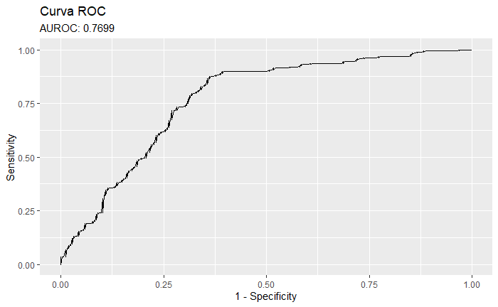

```r
graficar_curva_roc(modelo_log, datos_log_test, nivel_positivo = "true", var_respuesta = "diagnostico_pro")
```

Vamos a tratar de mejorar el AUC identificando observaciones influyentes para el modelo. Usamos la distancia de cook como métrica.

```r
data.frame(d_cook = cooks.distance(modelo_log$finalModel)) %>% arrange(- d_cook) %>% top_n(10)
```

|  | d_cook |
| --- | --- |
| X302 | 0.036990675 |
| X794 | 0.012932355 |
| X72 | 0.012132165 |
| X1256 | 0.011662661 |
| X2 | 0.009957387 |
| X34 | 0.009271904 |
| X105 | 0.007882900 |
| X978 | 0.006788300 |
| X1446 | 0.006714322 |
| X276 | 0.006342943 |

Observamos que la observación 302 es la que se encuentra más alejada del resto, por lo que vamos a probar entrenando otro modelo sin esa observación.

```r
nro_fila_influyente <- 302

# Observamos como es ese registro
datos_log[nro_fila_influyente,]
```

| diagnostico_pro | d1 | d2 | d3 | d4 | d5 | edad | id |
| --- | --- | --- | --- | --- | --- | --- | --- |
| true | 31.25084 | -29.34192 | 0.363726 | 0.08329 | 0.012357 | 51 | 21530 |

```r
# Excluimos la observacion
datos_log_sin_inf <- datos_log[-nro_fila_influyente,]

# Realizamos la particion de vuelta
set.seed(SEED)
indices_train_inf <- createDataPartition(datos_log_sin_inf$diagnostico_pro,
                                         p = PORCENTAJE_TRAIN,
                                         list = FALSE) %>%
  as.vector()

datos_log_inf_train <- datos_log_sin_inf[indices_train_inf,]
datos_log_inf_test <- datos_log_sin_inf[- indices_train_inf,]

# Verifiquemos que se cree correctamente
nrow(datos_log_inf_train)
```

```
[1] 1775
```

```r
nrow(datos_log_inf_test)
```

```
[1] 442
```

Habiendo hecho la partición, ajustamos el modelo

```r
modelo_log_inf <- train(diagnostico_pro ~ .,
                        datos_log_inf_train %>% select(-id),
                        method = "glm",
                        family = "binomial")

summary(modelo_log_inf)
```

```
Call:
NULL

Deviance Residuals:
    Min       1Q   Median       3Q      Max
-2.6449  -0.7126  -0.3880   0.8017   2.4436

Coefficients:
             Estimate Std. Error z value Pr(>|z|)
(Intercept) -8.946940   0.504800 -17.724  < 2e-16 ***
d1           0.090273   0.014234   6.342 2.27e-10 ***
d2          -0.005529   0.002477  -2.232   0.0256 *
d3           0.399593   0.450443   0.887   0.3750
d4          -0.496162   2.980262  -0.166   0.8678
d5          -1.188001   3.255992  -0.365   0.7152
edad         0.110629   0.005763  19.197  < 2e-16 ***
---
Signif. codes:  0 ‘***’ 0.001 ‘**’ 0.01 ‘*’ 0.05 ‘.’ 0.1 ‘ ’ 1

(Dispersion parameter for binomial family taken to be 1)

    Null deviance: 2419.1  on 1774  degrees of freedom
Residual deviance: 1751.4  on 1768  degrees of freedom
AIC: 1765.4

Number of Fisher Scoring iterations: 4
```

Comparando con el primer modelo de logístico armado, los coeficientes son similares.

Armamos de nuevo la curva ROC

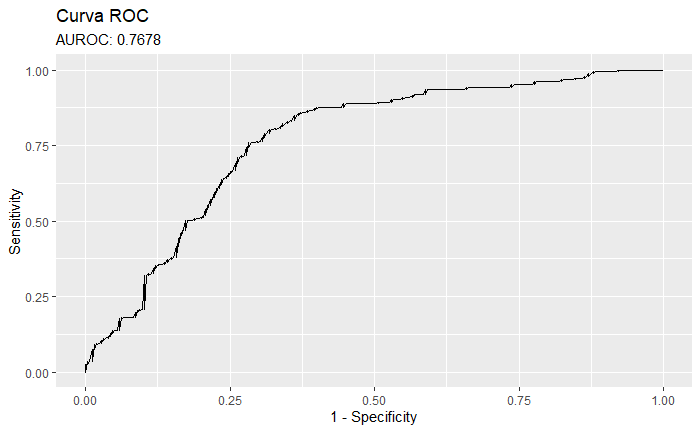

```r
graficar_curva_roc(modelo_log_inf, datos_log_inf_test, "true", "diagnostico_pro")
```

Se observa que el AUC es el mismo, así que no excluimos esa observación.

Ahora lo que hacemos es graficar specificity vs sensitivity para todos los posibles puntos de corte

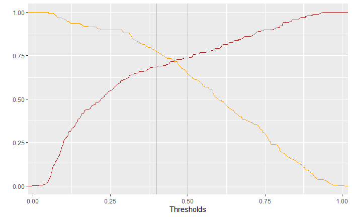

```r
# Primero creamos un objeto roc
predicciones_log <- predict(modelo_log, datos_log_test, list = FALSE, type = "prob")
objeto_roc_log <- roc(datos_log_test$diagnostico_pro, predicciones_log[, "true"])
# Armamos el grafico
data.frame(Specificity = objeto_roc_log$specificities,
           Sencitivity = objeto_roc_log$sensitivities,
           Thresholds = objeto_roc_log$thresholds) %>%
  ggplot(aes(x = Thresholds)) +
  geom_line(aes(y = Specificity), color = "firebrick") +
  geom_line(aes(y = Sencitivity), color = "orange") +
  geom_vline(xintercept = .5, color = "gray") +
  geom_vline(xintercept = .4, color = "gray") +
  ylab("")
```

Observamos que el punto de intersección se encuentra en algún punto entre 0.4 y 0.5. Elegimos el punto 0.44 como punto de corte para armar una matriz de confusión.

```r
# Hacemos las predicciones usando 0.44 como punto de corte
prediccioes_log_matriz_confusion <- ifelse(predicciones_log[, "true"] >= 0.44,
                                           "true",
                                           "false") %>%
  as.factor()

# Armamos la matriz de confusion
confusionMatrix(prediccioes_log_matriz_confusion,
                datos_log_test$diagnostico_pro,
                positive = "true")
```

```
Confusion Matrix and Statistics

          Reference
Prediction false true
     false   180   50
     true     75  138

               Accuracy : 0.7178
                 95% CI : (0.6734, 0.7593)
    No Information Rate : 0.5756
    P-Value [Acc > NIR] : 4.088e-10

                  Kappa : 0.4324

 Mcnemar's Test P-Value : 0.03182

            Sensitivity : 0.7340
            Specificity : 0.7059
         Pos Pred Value : 0.6479
         Neg Pred Value : 0.7826
             Prevalence : 0.4244
         Detection Rate : 0.3115
   Detection Prevalence : 0.4808
      Balanced Accuracy : 0.7200

       'Positive' Class : true
```

# Naive Bayes

```r
datos_bayes <- datos %>%
  select(all_of(VARIABLES_BAYES))
glimpse(datos_bayes)
```

```
Rows: 2,218
Columns: 23
$ id                                             <int> 24665, 21472, 25155, 22829, 24848, 21417, 25652, 23500, 22216, 23967, 24861, 23331, 27236,...
$ d1                                             <dbl> 35.23343, 35.06466, 53.76691, 31.19639, 36.34814, 34.78511, 35.44090, 34.05800, 30.03747, ...
$ es_cuidador                                    <fct> true, false, false, false, false, false, false, false, false, false, false, false, false, ...
$ educ                                           <fct> High School Diploma/GED, Some college, Some college, High School Diploma/GED, 4-year colle...
$ empleo                                         <fct> Retired, Employment for wages, Retired, Self-employed, Self-employed, Employment for wages...
$ estado_marital                                 <fct> Married or domestic partnership, Married or domestic partnership, Married or domestic part...
$ facilidad_celular                              <fct> Neither easy nor difficult, Very easy, Neither easy nor difficult, Very easy, Very easy, V...
$ fumo                                           <fct> false, false, true, false, true, false, false, true, true, NA, false, false, true, false, ...
$ diagnostico_pro                                <fct> true, false, true, true, true, true, true, true, true, false, true, true, true, true, true...
$ F0semitoneFrom27.5Hz_sma3nz_amean              <dbl> 35.23343, 35.06466, 53.76691, 31.19639, 36.34814, 34.78511, 35.44090, 34.05800, 30.03747, ...
$ F0semitoneFrom27.5Hz_sma3nz_stddevNorm         <dbl> 0.161030600, 0.106669900, 0.182087500, 0.162401300, 0.054965090, 0.029149800, 0.137568600,...
$ F0semitoneFrom27.5Hz_sma3nz_percentile20.0     <dbl> 29.45055, 32.44142, 40.43331, 27.96030, 35.96183, 34.87170, 31.16132, 30.70759, 25.74033, ...
$ F0semitoneFrom27.5Hz_sma3nz_percentile50.0     <dbl> 38.55538, 35.82104, 60.42034, 28.52856, 36.04095, 34.96726, 35.51604, 31.45276, 30.50913, ...
$ F0semitoneFrom27.5Hz_sma3nz_percentile80.0     <dbl> 38.83738, 37.60675, 61.26674, 36.90845, 36.11494, 35.31850, 39.28172, 38.77784, 34.38029, ...
$ F0semitoneFrom27.5Hz_sma3nz_pctlrange0.2       <dbl> 9.3868220, 5.1653330, 20.8334300, 8.9481430, 0.1531143, 0.4468040, 8.1204030, 8.0702460, 8...
$ F0semitoneFrom27.5Hz_sma3nz_meanRisingSlope    <dbl> 114.184400, 118.410000, 429.490600, 419.248900, 240.982300, 24.008520, 177.705700, 227.539...
$ F0semitoneFrom27.5Hz_sma3nz_stddevRisingSlope  <dbl> 56.084000, 107.292700, 689.398400, 321.385000, 241.473500, 19.655140, 95.663720, 235.50510...
$ F0semitoneFrom27.5Hz_sma3nz_meanFallingSlope   <dbl> 97.8847400, 80.9920900, 127.1325000, 254.6380000, 121.1082000, 14.4527100, 243.6435000, 13...
$ F0semitoneFrom27.5Hz_sma3nz_stddevFallingSlope <dbl> 182.2504000, 77.6166200, 122.9650000, 53.7106300, 112.5608000, 7.6812340, 355.1958000, 75....
$ jitterLocal_sma3nz_amean                       <dbl> 0.032114240, 0.024917370, 0.058174750, 0.069262010, 0.005820125, 0.016125760, 0.064558510,...
$ jitterLocal_sma3nz_stddevNorm                  <dbl> 2.3007530, 1.2594430, 0.6680026, 0.9678657, 3.4096500, 1.5260270, 0.7939821, 1.4232170, 0....
$ shimmerLocaldB_sma3nz_amean                    <dbl> 0.7523836, 1.4177130, 1.8616870, 2.2524320, 0.2753830, 0.7553201, 1.6553570, 1.0649890, 1....
$ shimmerLocaldB_sma3nz_stddevNorm               <dbl> 1.0762190, 0.5639182, 0.2690561, 0.5869845, 2.2129440, 0.6460580, 0.5272198, 0.9272277, 0....
```

Primero observamos los NAs en las variables que vamos a usar en el modelo

```r
vector_cant_nas <- datos_bayes %>%
  map_int(~ sum(is.na(.x)))

vector_cant_nas[vector_cant_nas > 0] %>% sort(decreasing = TRUE)
```

```
             fumo            empleo              educ    estado_marital       es_cuidador facilidad_celular
               65                 8                 7                 4                 3                 1
```

Para tratar los NAs vamos a tomar dos caminos:

- Vamos a hacer un modelo donde los NAs son sustitudos por el promedio o el nivel con mayor cantidad de observaciones.
- Vamos a hacer un modelo donde se eliminen los registros con NAs.

```r
# Reemplazamos los NAs
datos_bayes_con_na <- datos_bayes %>%
  mutate(es_cuidador = replace(es_cuidador, is.na(es_cuidador), "false"),
         educ = replace(educ, is.na(educ), "4-year college degree"),
         empleo = replace(empleo, is.na(empleo), "Employment for wages"),
         estado_marital = replace(estado_marital, is.na(estado_marital), "Married or domestic partnership"),
         facilidad_celular = replace(facilidad_celular, is.na(facilidad_celular), "Very easy"),
         fumo = replace(fumo, is.na(fumo), "false"))

# Elminamos los NAs
datos_bayes_sin_na <- datos_bayes %>%
  drop_na()

# Vemos como quedaron los datasets
paste("Cantidad de observaciones en datos con NAs reemplazados:", nrow(datos_bayes_con_na))
```

```
[1] "Cantidad de observaciones en datos con NAs reemplazados: 2218"
```

```r
paste("Cantidad de observaciones en datos con NAs eliminados:", nrow(datos_bayes_sin_na))
```

```
[1] "Cantidad de observaciones en datos con NAs eliminados: 2134"
```

## Con NAs sustitudos

Empezamos haciendo las particiones

```r
set.seed(SEED)
indices_train_bayes <- createDataPartition(datos_bayes_con_na$diagnostico_pro, p = PORCENTAJE_TRAIN, list = FALSE) %>%
  as.vector()

datos_bayes_con_na_train <- datos_bayes_con_na[indices_train_bayes, ]
datos_bayes_con_na_test <- datos_bayes_con_na[- indices_train_bayes, ]

nrow(datos_bayes_con_na_train)
```

```
[1] 1775
```

```r
nrow(datos_bayes_con_na_test)
```

```
[1] 443
```

Entrenamos el modelo con los datos de train

```r
modelo_bayes_con_na <- naiveBayes(diagnostico_pro ~ .,
                             data = datos_bayes_con_na_train %>% select(-id),
                             laplace = VALOR_LAPLACE)

modelo_bayes_con_na
```

```
Naive Bayes Classifier for Discrete Predictors

Call:
naiveBayes.default(x = X, y = Y, laplace = laplace)

A-priori probabilities:
Y
   false     true
0.576338 0.423662

Conditional probabilities:
       d1
Y           [,1]     [,2]
  false 26.48821 4.712961
  true  29.17006 4.988516

       es_cuidador
Y            false       true
  false 0.94243902 0.05756098
  true  0.91777188 0.08222812

       educ
Y       2-year college degree 4-year college degree Doctoral Degree High School Diploma/GED Masters Degree Some college Some graduate school
  false           0.064985451           0.253152279     0.128031038             0.047526673    0.242483026  0.173617847          0.080504365
  true            0.060526316           0.268421053     0.134210526             0.068421053    0.248684211  0.136842105          0.075000000
       educ
Y       Some high school
  false      0.009699321
  true       0.007894737

       empleo
Y       A homemaker   A student Employment for wages Out of work     Retired Self-employed Unable to work
  false 0.012621359 0.006796117          0.659223301 0.039805825 0.096116505   0.166990291    0.018446602
  true  0.022397892 0.001317523          0.287220026 0.007905138 0.457180501   0.123847167    0.100131752

       estado_marital
Y          Divorced Married or domestic partnership       Other   Separated Single never married     Widowed
  false 0.085519922                     0.750242954 0.003887269 0.014577259          0.130223518 0.015549077
  true  0.089709763                     0.811345646 0.010554090 0.014511873          0.038258575 0.035620053

```

[output cut: 64 more lines]

```

       jitterLocal_sma3nz_stddevNorm
Y           [,1]      [,2]
  false 2.014641 0.9734762
  true  1.873918 0.9879588

       shimmerLocaldB_sma3nz_amean
Y            [,1]      [,2]
  false 0.7818371 0.5334483
  true  0.7645742 0.5959549

       shimmerLocaldB_sma3nz_stddevNorm
Y            [,1]      [,2]
  false 0.9175357 0.3194395
  true  0.8650220 0.3088349
```

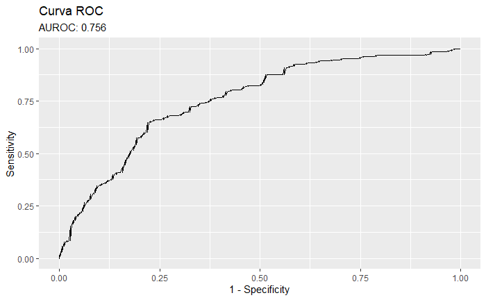

```r
graficar_curva_roc(modelo_bayes_con_na,
                   datos_bayes_con_na_test,
                   nivel_positivo = "true",
                   var_respuesta = "diagnostico_pro",
                   type_predict = "raw")
```

Vamos a tratar de mejorar está métrica, primero empecemos viendo si las variables numéricas se aproximan a una normal.

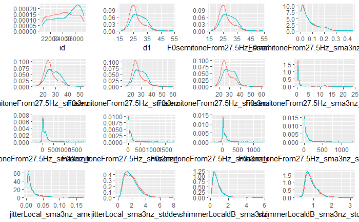

```r
nombres_variables <- datos_bayes_con_na %>%
  select(where(is.numeric)) %>%
  names()

graficos <- datos_bayes_con_na %>%
  select(where(is.numeric)) %>%
  map2(nombres_variables, ~ ggplot(datos_bayes_con_na, aes(.x, color = diagnostico_pro)) +
        geom_density(show.legend = FALSE) +
         xlab(.y) +
         ylab(""))


ggarrange(plotlist = graficos)
```

Ahora comparamos los mismos resultados aplicando una transformación logarítmica a los datos, solo a las variables que no observemos una densidad muy aleajada de la normal.

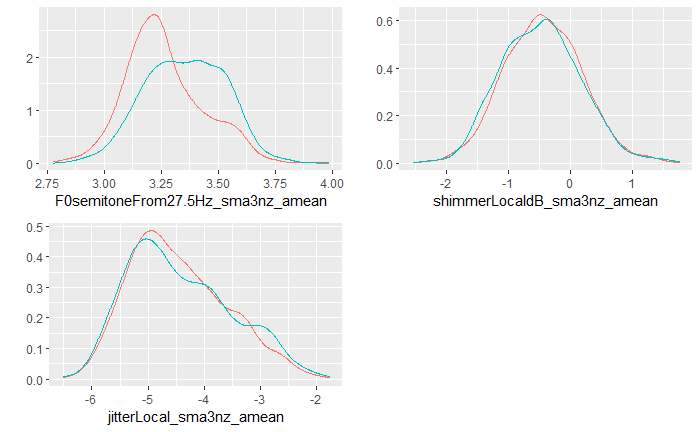

```r
vars_trans_log <- c("F0semitoneFrom27.5Hz_sma3nz_amean",
                    "shimmerLocaldB_sma3nz_amean",
                    "jitterLocal_sma3nz_amean")

graficos <- datos_bayes_con_na %>%
  select(all_of(vars_trans_log)) %>%
  map2(vars_trans_log, ~ ggplot(datos_bayes_con_na, aes(log(.x), color = diagnostico_pro)) +
        geom_density(show.legend = FALSE) +
         xlab(.y) +
         ylab(""))

ggarrange(plotlist = graficos)
```

Creamos un nuevo dataset con las variables transformadas

```r
datos_bayes_con_na_log <- datos_bayes_con_na %>%
  mutate(F0semitoneFrom27.5Hz_sma3nz_amean = log(F0semitoneFrom27.5Hz_sma3nz_amean),
  shimmerLocaldB_sma3nz_amean = log(shimmerLocaldB_sma3nz_amean),
  jitterLocal_sma3nz_amean = log(jitterLocal_sma3nz_amean))
```

Volvemos a realizar la partición y entrenamos el modelo

```r
set.seed(SEED)
indices_train_bayes <- createDataPartition(datos_bayes_con_na_log$diagnostico_pro,
                                           p = PORCENTAJE_TRAIN,
                                           list = FALSE) %>%
  as.vector()

datos_bayes_con_na_log_train <- datos_bayes_con_na_log[indices_train_bayes, ]
datos_bayes_con_na_log_test <- datos_bayes_con_na_log[-indices_train_bayes, ]

# Verificamos
nrow(datos_bayes_con_na_log) == nrow(datos_bayes_con_na_log_train) + nrow(datos_bayes_con_na_log_test)
```

```
[1] TRUE
```

Ahora entrenamos el modelo

```r
modelo_bayes_con_na_log <- naiveBayes(diagnostico_pro ~ .,
                                      datos_bayes_con_na_log_train %>% select(-id),
                                      laplace = VALOR_LAPLACE)

modelo_bayes_con_na_log
```

```
Naive Bayes Classifier for Discrete Predictors

Call:
naiveBayes.default(x = X, y = Y, laplace = laplace)

A-priori probabilities:
Y
   false     true
0.576338 0.423662

Conditional probabilities:
       d1
Y           [,1]     [,2]
  false 26.48821 4.712961
  true  29.17006 4.988516

       es_cuidador
Y            false       true
  false 0.94243902 0.05756098
  true  0.91777188 0.08222812

       educ
Y       2-year college degree 4-year college degree Doctoral Degree High School Diploma/GED Masters Degree Some college Some graduate school
  false           0.064985451           0.253152279     0.128031038             0.047526673    0.242483026  0.173617847          0.080504365
  true            0.060526316           0.268421053     0.134210526             0.068421053    0.248684211  0.136842105          0.075000000
       educ
Y       Some high school
  false      0.009699321
  true       0.007894737

       empleo
Y       A homemaker   A student Employment for wages Out of work     Retired Self-employed Unable to work
  false 0.012621359 0.006796117          0.659223301 0.039805825 0.096116505   0.166990291    0.018446602
  true  0.022397892 0.001317523          0.287220026 0.007905138 0.457180501   0.123847167    0.100131752

       estado_marital
Y          Divorced Married or domestic partnership       Other   Separated Single never married     Widowed
  false 0.085519922                     0.750242954 0.003887269 0.014577259          0.130223518 0.015549077
  true  0.089709763                     0.811345646 0.010554090 0.014511873          0.038258575 0.035620053

```

[output cut: 64 more lines]

```

       jitterLocal_sma3nz_stddevNorm
Y           [,1]      [,2]
  false 2.014641 0.9734762
  true  1.873918 0.9879588

       shimmerLocaldB_sma3nz_amean
Y             [,1]      [,2]
  false -0.4350024 0.6105848
  true  -0.4841771 0.6406685

       shimmerLocaldB_sma3nz_stddevNorm
Y            [,1]      [,2]
  false 0.9175357 0.3194395
  true  0.8650220 0.3088349
```

Dibujamos la curva ROC y AUROC

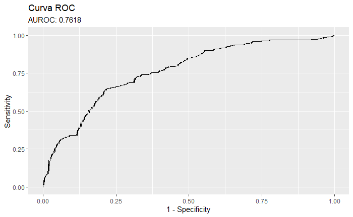

```r
graficar_curva_roc(modelo_bayes_con_na_log,
                   datos_bayes_con_na_log_test,
                   nivel_positivo = "true",
                   var_respuesta = "diagnostico_pro",
                   type_predict = "raw")
```

Para seguir tratando de mejorar el modelo vamos a re-organizar las categorías de las variables cualitativas, ya que hay varías que se encuentran con niveles desbalanceados.

```r
datos_bayes_con_na_refactor <- datos_bayes_con_na


# Dividir educ en Posgraduate - College - Highschool
datos_bayes_con_na_refactor <- datos_bayes_con_na_refactor %>%
  mutate(educ = fct_collapse(educ,
                           "Postgraduate" = c("Doctoral Degree", "Masters Degree"),
                           "College" = c("2-year college degree", "4-year college degree", "Some graduate school"),
                           "HighSchool" = c("High School Diploma/GED", "Some college", "Some high school")))

# Emplemos lo agrupamos en Working - Not Working
datos_bayes_con_na_refactor <- datos_bayes_con_na_refactor %>%
  mutate(empleo = fct_collapse(empleo,
                               "Working" = c("A homemaker", "Employment for wages", "Self-employed"),
                               "Not Working" = c("A student", "Out of work", "Retired", "Unable to work" )))

# Estado marital lo convertimos en Married - Not Married
datos_bayes_con_na_refactor <- datos_bayes_con_na_refactor %>%
  mutate(estado_marital = fct_collapse(estado_marital,
                                       "Married" = c("Married or domestic partnership"),
                                       "Not Married" = c("Divorced", "Other", "Separated", "Single never married", "Widowed")))

# Para facilidad celular lo convertimos en Easy - Not Easy
datos_bayes_con_na_refactor <- datos_bayes_con_na_refactor %>%
  mutate(facilidad_celular = fct_collapse(facilidad_celular,
                                    "Not Easy" = c("Difficult", "Neither easy nor difficult", "Very Difficult"),
                                    "Easy" = c("Easy", "Very easy")))
```

Volvemos a particionar, entrenar el modelo y graficar la curva ROC

```r
set.seed(SEED)
indices_train_bayes <- createDataPartition(datos_bayes_con_na_refactor$diagnostico_pro,
                                           p = PORCENTAJE_TRAIN,
                                           list = FALSE) %>%
  as.vector()

datos_bayes_con_na_refactor_train <- datos_bayes_con_na_refactor[indices_train_bayes,]
datos_bayes_con_na_refactor_test <- datos_bayes_con_na_refactor[-indices_train_bayes,]

# Verificamos
nrow(datos_bayes_con_na_refactor) == nrow(datos_bayes_con_na_refactor_train) + nrow(datos_bayes_con_na_refactor_test)
```

```
[1] TRUE
```

```r
modelo_bayes_con_na_refactor <- naiveBayes(diagnostico_pro ~ .,
                                           datos_bayes_con_na_refactor_train %>% select(-id),
                                           laplace = VALOR_LAPLACE)

modelo_bayes_con_na_refactor
```

```
Naive Bayes Classifier for Discrete Predictors

Call:
naiveBayes.default(x = X, y = Y, laplace = laplace)

A-priori probabilities:
Y
   false     true
0.576338 0.423662

Conditional probabilities:
       d1
Y           [,1]     [,2]
  false 26.48821 4.712961
  true  29.17006 4.988516

       es_cuidador
Y            false       true
  false 0.94243902 0.05756098
  true  0.91777188 0.08222812

       educ
Y         College Postgraduate HighSchool
  false 0.3986355    0.3713450  0.2300195
  true  0.4039735    0.3841060  0.2119205

       empleo
Y         Working Not Working
  false 0.8409756   0.1590244
  true  0.4336870   0.5663130

       estado_marital
Y       Not Married   Married
  false   0.2468293 0.7531707
  true    0.1843501 0.8156499

       facilidad_celular
Y         Not Easy       Easy
  false 0.01658537 0.98341463
  true  0.21220159 0.78779841
```

[output cut: 60 more lines]

```

       jitterLocal_sma3nz_stddevNorm
Y           [,1]      [,2]
  false 2.014641 0.9734762
  true  1.873918 0.9879588

       shimmerLocaldB_sma3nz_amean
Y            [,1]      [,2]
  false 0.7818371 0.5334483
  true  0.7645742 0.5959549

       shimmerLocaldB_sma3nz_stddevNorm
Y            [,1]      [,2]
  false 0.9175357 0.3194395
  true  0.8650220 0.3088349
```

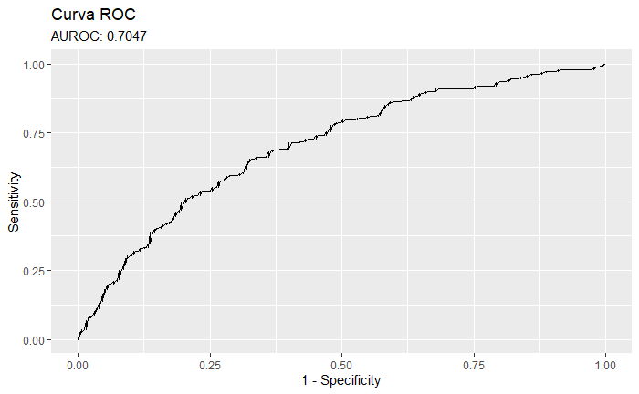

```r
graficar_curva_roc(modelo_bayes_con_na_refactor,
                   datos_bayes_con_na_refactor_test,
                   nivel_positivo = "true",
                   var_respuesta = "diagnostico_pro",
                   type_predict = "raw")
```

Empeoro el AUC en este caso

Por último, probamos un modelo en un dataset que incluye tanto las transformaciones logaritmicas como la reorganización de los factores.

```r
variables_categoricas <- datos_bayes_con_na_refactor %>% select(where(is.factor))
variables_cuanti <- datos_bayes_con_na_log %>% select(where(is.numeric))
datos_bayes_con_na_log_refactor <- cbind(variables_categoricas, variables_cuanti)

# Para verificar
nrow(datos_bayes_con_na_log_refactor) == nrow(datos_bayes)
```

```
[1] TRUE
```

```r
ncol(datos_bayes_con_na_log_refactor) == ncol(datos_bayes)
```

```
[1] TRUE
```

```r
set.seed(SEED)
indices_train_bayes <- createDataPartition(datos_bayes_con_na_log_refactor$diagnostico_pro,
                                           p = PORCENTAJE_TRAIN,
                                           list = FALSE) %>%
  as.vector()

datos_bayes_con_na_log_refactor_train <- datos_bayes_con_na_log_refactor[indices_train_bayes,]
datos_bayes_con_na_log_refactor_test <- datos_bayes_con_na_log_refactor[-indices_train_bayes,]

# Verificacion
nrow(datos_bayes_con_na_log_refactor) == nrow(datos_bayes_con_na_log_refactor_train) + nrow(datos_bayes_con_na_log_refactor_test)
```

```
[1] TRUE
```

```r
modelo_bayes_con_na_log_refactor <- naiveBayes(diagnostico_pro ~ .,
                                               datos_bayes_con_na_log_refactor_train %>% select(-id),
                                               laplace = VALOR_LAPLACE)
modelo_bayes_con_na_log_refactor
```

```
Naive Bayes Classifier for Discrete Predictors

Call:
naiveBayes.default(x = X, y = Y, laplace = laplace)

A-priori probabilities:
Y
   false     true
0.576338 0.423662

Conditional probabilities:
       es_cuidador
Y            false       true
  false 0.94243902 0.05756098
  true  0.91777188 0.08222812

       educ
Y         College Postgraduate HighSchool
  false 0.3986355    0.3713450  0.2300195
  true  0.4039735    0.3841060  0.2119205

       empleo
Y         Working Not Working
  false 0.8409756   0.1590244
  true  0.4336870   0.5663130

       estado_marital
Y       Not Married   Married
  false   0.2468293 0.7531707
  true    0.1843501 0.8156499

       facilidad_celular
Y         Not Easy       Easy
  false 0.01658537 0.98341463
  true  0.21220159 0.78779841

       fumo
Y           false      true
  false 0.6517073 0.3482927
  true  0.6618037 0.3381963
```

[output cut: 60 more lines]

```

       jitterLocal_sma3nz_stddevNorm
Y           [,1]      [,2]
  false 2.014641 0.9734762
  true  1.873918 0.9879588

       shimmerLocaldB_sma3nz_amean
Y             [,1]      [,2]
  false -0.4350024 0.6105848
  true  -0.4841771 0.6406685

       shimmerLocaldB_sma3nz_stddevNorm
Y            [,1]      [,2]
  false 0.9175357 0.3194395
  true  0.8650220 0.3088349
```

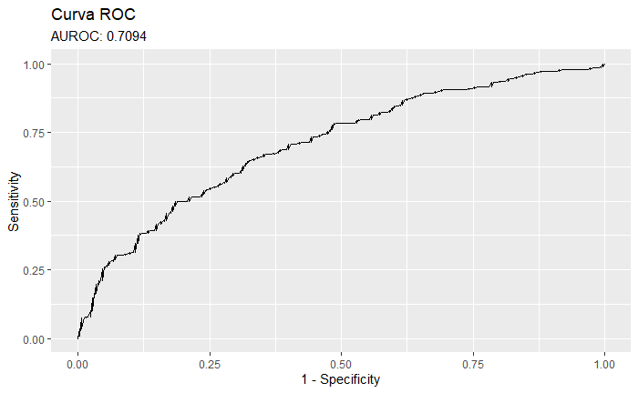

```r
graficar_curva_roc(modelo_bayes_con_na_log_refactor,
                   datos_bayes_con_na_log_refactor_test, nivel_positivo = "true",
                   var_respuesta = "diagnostico_pro",
                   type_predict = "raw")
```

## Con NAs eliminados

Realizamos la partición

```r
set.seed(SEED)
indices_train_bayes <- createDataPartition(datos_bayes_sin_na$diagnostico_pro, p = PORCENTAJE_TRAIN,  list = FALSE) %>%
  as.vector()

datos_bayes_sin_na_train <- datos_bayes_sin_na[indices_train_bayes, ]
datos_bayes_sin_na_test <- datos_bayes_sin_na[- indices_train_bayes, ]

# Verificamos
nrow(datos_bayes_sin_na) == nrow(datos_bayes_sin_na_train) + nrow(datos_bayes_sin_na_test)
```

```
[1] TRUE
```

Ahora ajustamos el modelo

```r
modelo_bayes_sin_na <- naiveBayes(diagnostico_pro ~ .,
                                  datos_bayes_sin_na_train %>% select(-id),
                                  laplace = VALOR_LAPLACE)

modelo_bayes_sin_na
```

```
Naive Bayes Classifier for Discrete Predictors

Call:
naiveBayes.default(x = X, y = Y, laplace = laplace)

A-priori probabilities:
Y
    false      true
0.5638173 0.4361827

Conditional probabilities:
       d1
Y           [,1]     [,2]
  false 26.41945 4.598852
  true  29.21586 5.068456

       es_cuidador
Y            false       true
  false 0.94611399 0.05388601
  true  0.92101740 0.07898260

       educ
Y       2-year college degree 4-year college degree Doctoral Degree High School Diploma/GED Masters Degree Some college Some graduate school
  false           0.061791967           0.283213182     0.120494336             0.042224511    0.232749743  0.170957775          0.080329557
  true            0.066401062           0.252324037     0.132802125             0.066401062    0.258964143  0.135458167          0.079681275
       educ
Y       Some high school
  false      0.008238929
  true       0.007968127

       empleo
Y       A homemaker   A student Employment for wages Out of work     Retired Self-employed Unable to work
  false 0.011340206 0.010309278          0.650515464 0.044329897 0.107216495   0.158762887    0.017525773
  true  0.021276596 0.001329787          0.280585106 0.010638298 0.440159574   0.135638298    0.110372340

       estado_marital
Y          Divorced Married or domestic partnership       Other   Separated Single never married     Widowed
  false 0.079463364                     0.759545924 0.003095975 0.012383901          0.132094943 0.013415893
  true  0.097203728                     0.809587217 0.007989348 0.013315579          0.039946738 0.031957390

```

[output cut: 64 more lines]

```

       jitterLocal_sma3nz_stddevNorm
Y           [,1]      [,2]
  false 2.012540 0.9941133
  true  1.874011 0.9677639

       shimmerLocaldB_sma3nz_amean
Y            [,1]      [,2]
  false 0.8074727 0.5999212
  true  0.7655993 0.6028336

       shimmerLocaldB_sma3nz_stddevNorm
Y            [,1]      [,2]
  false 0.9118511 0.3223184
  true  0.8756416 0.3181229
```

Graficamos la cruva ROC

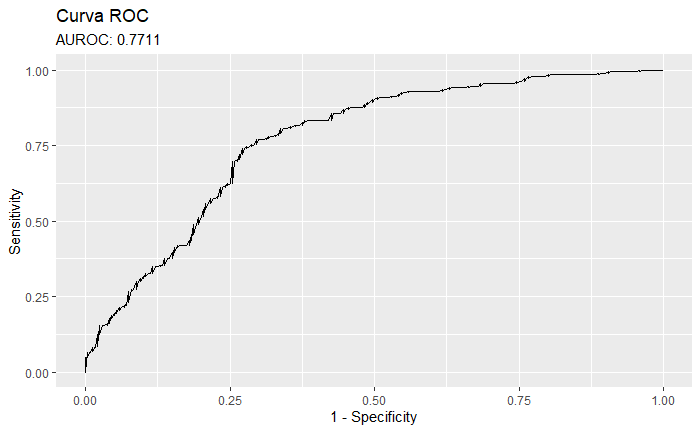

```r
graficar_curva_roc(modelo_bayes_sin_na,
                   datos_bayes_sin_na_test,
                   nivel_positivo = "true",
                   var_respuesta = "diagnostico_pro",
                   type_predict = "raw")
```

# Evaluación de los modelos

```r
proporciones <- seq(0.05, .35, .05)
```

## Regresión Logística

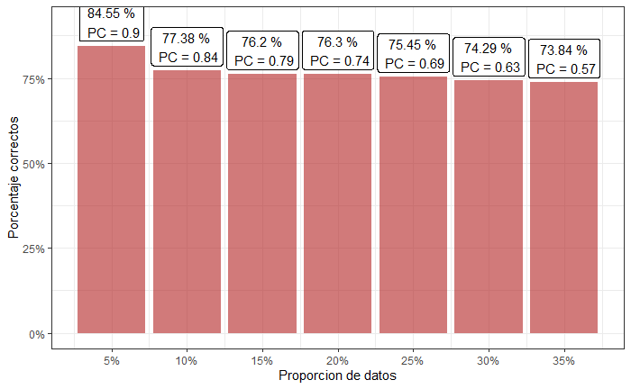

```r
evaluar_modelo_metodo_silvia(modelo_log,
                             datos_log,
                             proporciones,
                             nombre_var_respuesta = "diagnostico_pro",
                             nombre_var_ids = "id")
```

```r
#aux <- crear_df_evaluacion(modelo_log,
#                    datos_log, nombre_var_respuesta = "diagnostico_pro", nombre_var_ids = "id", nivel_positivo = "true", type_predict = "prob")
```

## Naive Bayes

Primero corremos el mejor modelo de bayes con los NAs reemplazados.

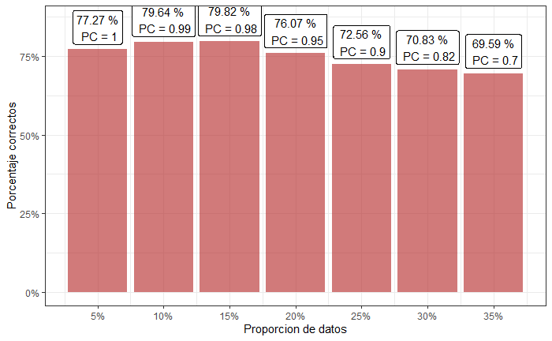

```r
evaluar_modelo_metodo_silvia(modelo_bayes_con_na_log,
                             datos_bayes_con_na_log,
                             proporciones,
                             nombre_var_respuesta = "diagnostico_pro",
                             nombre_var_ids = "id",
                             type_predict = "raw")
```

```r
#crear_df_evaluacion(modelo_bayes_con_na_log,
#                             datos_bayes_con_na_log,
#                             nombre_var_respuesta = "diagnostico_pro",
#                             nombre_var_ids = "id",
#                             type_predict = "raw",
#                  nivel_positivo = "true")
```

Ahora corremos el modelo de bayes con los NAs eliminados

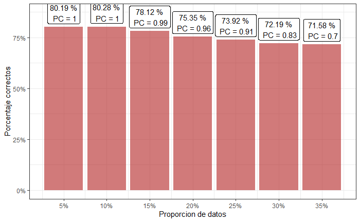

```r
evaluar_modelo_metodo_silvia(modelo_bayes_sin_na,
                             datos_bayes_sin_na,
                             proporciones,
                             nombre_var_respuesta = "diagnostico_pro",
                             nombre_var_ids = "id",
                             type_predict = "raw")
```